# Transmission and fuel consumption analysis

#### Executive summary

The main goal of this analysis is using the `mtcars` dataset to answer two questions:

- is an automatic or manual transmission better for `mpg`?
- quantify the `mpg` difference between automatic and manual transmissions;

`mpg` being *miles per gallon*, an indicator of fuel consumption. The results are as follows: the main effect of transmission, `am`, on consumption, is relevant: the `mpg` mean for automatic transmission car is 17.1474 while the `mpg` mean for manual transmission car is 24.3923, *0* being automatic transmission, and *1* the manual one. It seems that cars with manual transmission has less fuel consumption on average, but analyzing data and hearing the domain experts opinion, I have detected a possible confounding variable, weight - `wt`. As you will see in the rest of the analysis, automatic tranmission cars tend to weigh more, and weight is able to explain all the relationship between `mpg` and `am`. At the end of the analysis I’ll try to idenfity a parsimonious model to predict `mpg`.

#### Exploratory data analysis

The `mtcars` dataset is composed by 32 observations and 11 variables, for details please look at `?mtcars` on the R console. There are no missing values. At the appendix you find the plot *Scatterplot matrix*, extremely useful to orient the modeling. Infact you can see that the graph representing `wt` and `am` shows how the two groups are almost not overlapped. This, in addition to domain experts opinions, prompted me to adjust the relationship between `mpg` and `am` for `wt` at first.

#### Adjustement

Let’s remind the main effect of `am` on `mpg`:the `mpg` mean for automatic transmission car is 17.1474 while the `mpg` mean for manual transmission car is 24.3923. This difference in means is also statistically significant. Infact if we perform a one-way ANOVA with `aov` function we see that *F- statistic p.value* is 0.0002, and *etaSquared* is 0.3598. But if we adjust the relationship for `wt`, things change a lot. You can see this looking at the Appendix at plot *mpg vs am adjusted for wt*

Let’s see statistically what we showed in plots. First I will show the coefficients for the model, and then I will perform an ANOVA to demonstrate that accounting for `wt`makes `am` not necessary. Here are the coefficients for `lm(log(mpg) ~ wt + factor(am), mtcars)`

```
##             Estimate Std. Error t value  Pr(>|t|)
## (Intercept)  3.89834    0.13567 28.7345 7.374e-23
## wt          -0.28699    0.03501 -8.1978 4.870e-09
## factor(am)1 -0.04307    0.06865 -0.6274 5.353e-01
```

According to this model (remember the log transformation of the response), for a unit increase of `wt`, the geometric mean of `mpg` is multiplied by $e^{\beta X_{wt}}$, 0.7505 (holding `am` constant). So it decreases, as expected. Furthermore, holding `wt` constant, moving from automatic to manual transmission change the intercept of a multiplying factor of 0.9578. We should be more accurate having some confidence intervals:

```
##               2.5 %   97.5 %
## (Intercept)  3.6209  4.17582
## wt          -0.3586 -0.21539
## factor(am)1 -0.1835  0.09733
```

Powering $e$ to lower and upper bound of `am` coefficient we see that intercept could be multiplied by 0.8324 or 1.1022. So we don’t even know if changing transmission, holding `wt`constant, decrease o increase `mpg`. Is `am` necessary for this model?

```r
anova(lm(log(mpg) ~ wt, mtcars), lm(log(mpg) ~ wt + factor(am), mtcars))
```

[output not shown]

Adding `am` in this case isn’t necessary, because p.value of the F statistics is 0.5353

#### A linear model

I would like to conclude this analysis fitting a linear model that, in according to parsimony principles, explain as much as possible `mpg` variance. I started with `wt` predictor, because R squared is high, 0.7976; after that I tried to include a third variable, looking for significant predictors. I have started with `hp`, which is significant (in the model I divided it by 100 for interpretability of coefficients), and after that no fourth variable seemed statistically necessary to the model. Here are the coefficients of `lm(log(mpg) ~ wt + I(hp/100), mtcars)`:

```
##             Estimate Std. Error t value  Pr(>|t|)
## (Intercept)   3.8291    0.06868  55.752 4.716e-31
## wt           -0.2005    0.02718  -7.378 3.962e-08
## I(hp/100)    -0.1543    0.03879  -3.979 4.234e-04
```

R squared adjusted is 0.8691, and the variance inflation factors are low, 1.7666for `wt`and 1.7666for `hp`. In the appendix you can find the *diagnostic plot for mpg ~ wt + hp*, which shows that homoschedasticity and normality of residuals are not so well respected, but probably acceptable for our purposes (p.value of a *shapiro test for normality of residuals* is 0.2701). I decided to not remove outlier, because are due to specific properties of some units of the sample.

#### Appendix

##### Scatterplot matrix

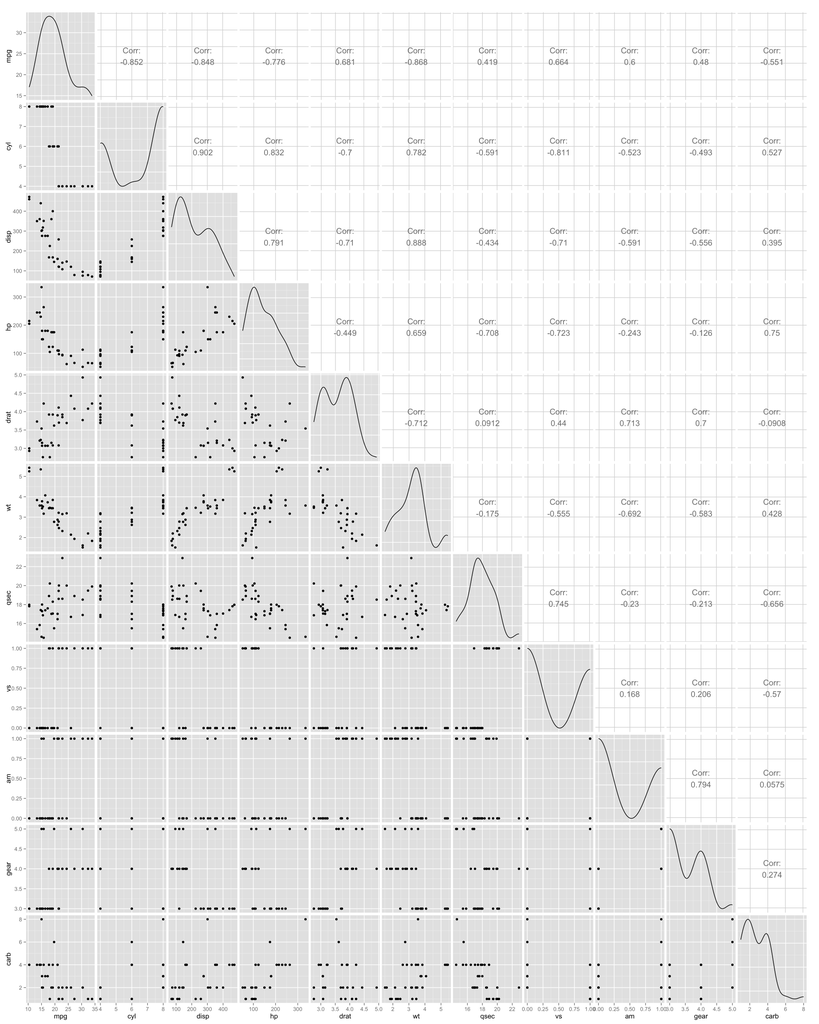

##### Adjustments

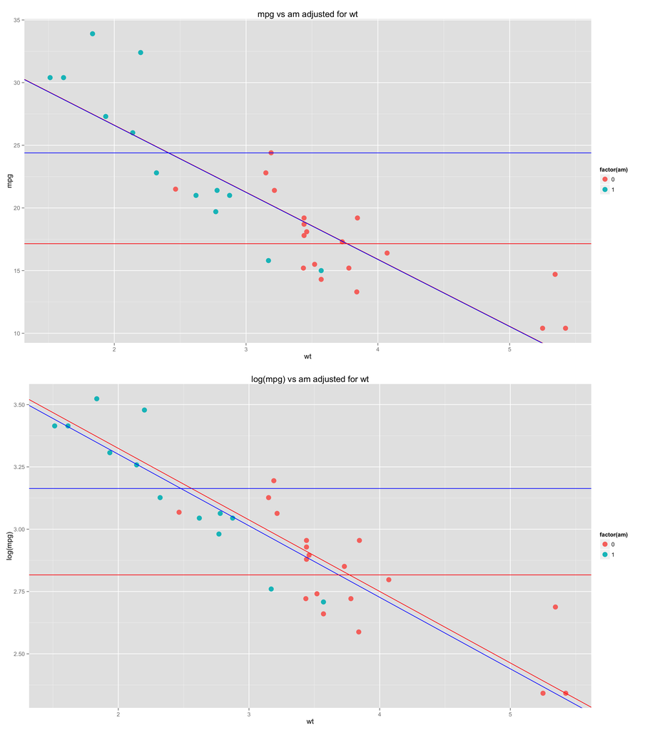

##### Diagnostic plot

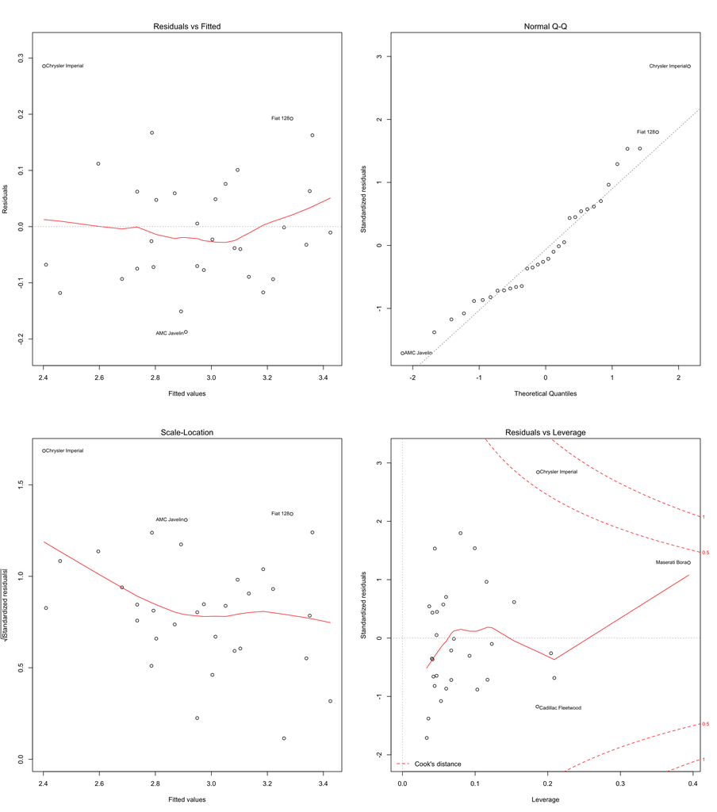